# Nutrient tradeoffs among species

Compiled on Tue Aug 14 19:03:03 2018

# What is the distribution of cover in the control plot?

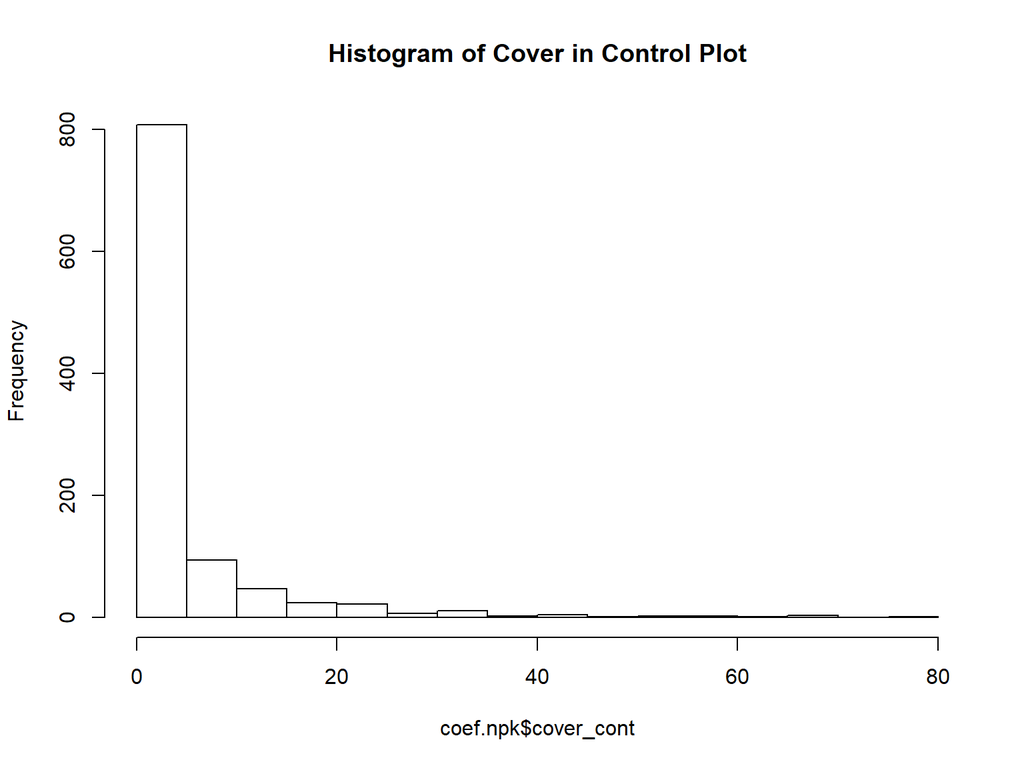

# Tradeoffs facetted by cover in control plot

Consistent with the above histogram, a large number of observations fall within the first grouping of cover values between 0 - 1%. Given our correction made earlier (+.01), I suspect that many of these correspond to zero values. As we focus more on more abundant species, the patterns seem to become less linear.

Some of these values are quite surprising. While it’s reasonable to note that very rare species have LRRs of >10, LRR scores of 5 or more in very common species seem odd. With log2() transformation, an LRR of 5 corresponds to a 32-fold change.

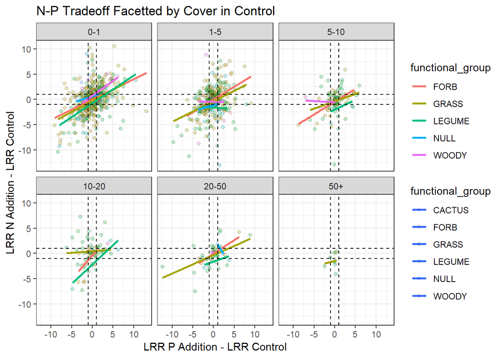

```r
ggplot(coef.npk,
       aes(y=LRR_N,
           x=LRR_P,
           color=functional_group,
           fill=functional_group)) +
  facet_wrap(~controlcover) +
  geom_point(aes(color = NULL), shape = 21, alpha = .25) +
  geom_smooth(method='lm', se=F) +
  geom_hline(yintercept=-1,linetype='dashed') +
  geom_vline(xintercept=-1,linetype='dashed') +
  geom_hline(yintercept=1,linetype='dashed') +
  geom_vline(xintercept=1,linetype='dashed') +
  theme_bw() +
  labs(x='LRR P Addition - LRR Control',y='LRR N Addition - LRR Control') +
  ggtitle("N-P Tradeoff Facetted by Cover in Control")
```

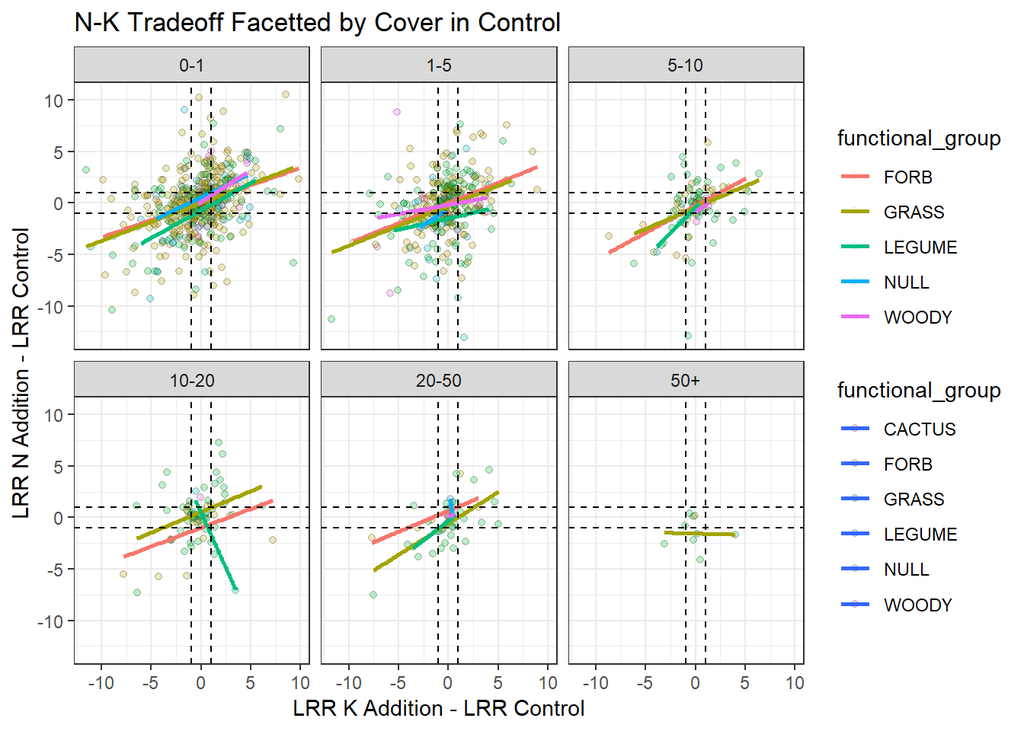

```r
ggplot(coef.npk,
       aes(y=LRR_N,
           x=LRR_K,
           color=functional_group,
           fill=functional_group)) +
  facet_wrap(~controlcover) +
  geom_point(aes(color = NULL), shape = 21, alpha = .25) +
  geom_smooth(method='lm', se=F) +
  geom_hline(yintercept=-1,linetype='dashed') +
  geom_vline(xintercept=-1,linetype='dashed') +
  geom_hline(yintercept=1,linetype='dashed') +
  geom_vline(xintercept=1,linetype='dashed') +
  theme_bw() +
  labs(x='LRR K Addition - LRR Control',y='LRR N Addition - LRR Control') +
  ggtitle("N-K Tradeoff Facetted by Cover in Control")
```

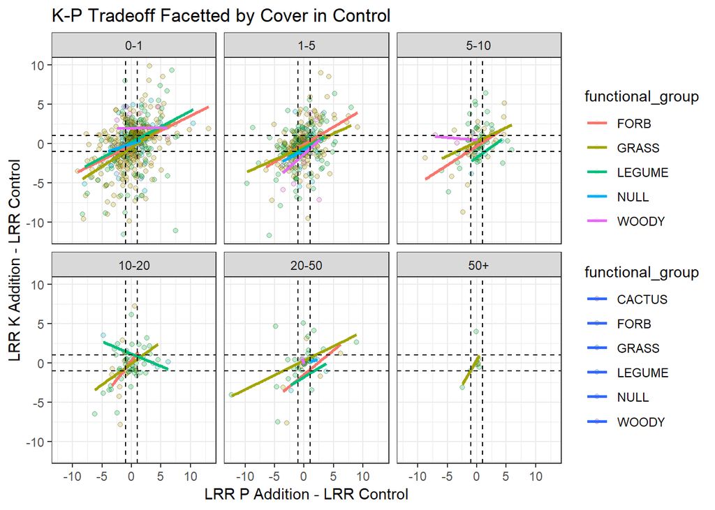

```r
ggplot(coef.npk,
       aes(y=LRR_K,
           x=LRR_P,
           color=functional_group,
           fill=functional_group)) +
  facet_wrap(~controlcover) +
  geom_point(aes(color = NULL), shape = 21, alpha = .25) +
  geom_smooth(method='lm', se=F) +
  geom_hline(yintercept=-1,linetype='dashed') +
  geom_vline(xintercept=-1,linetype='dashed') +
  geom_hline(yintercept=1,linetype='dashed') +
  geom_vline(xintercept=1,linetype='dashed') +
  theme_bw() +
  labs(x='LRR P Addition - LRR Control',y='LRR K Addition - LRR Control') +
  ggtitle("K-P Tradeoff Facetted by Cover in Control")
```

# Facetted by years of treatment

Strangely, I don’t see that treatment effect increases that much over time. Perhaps this is just a function of the sites that have received long-term treatments?

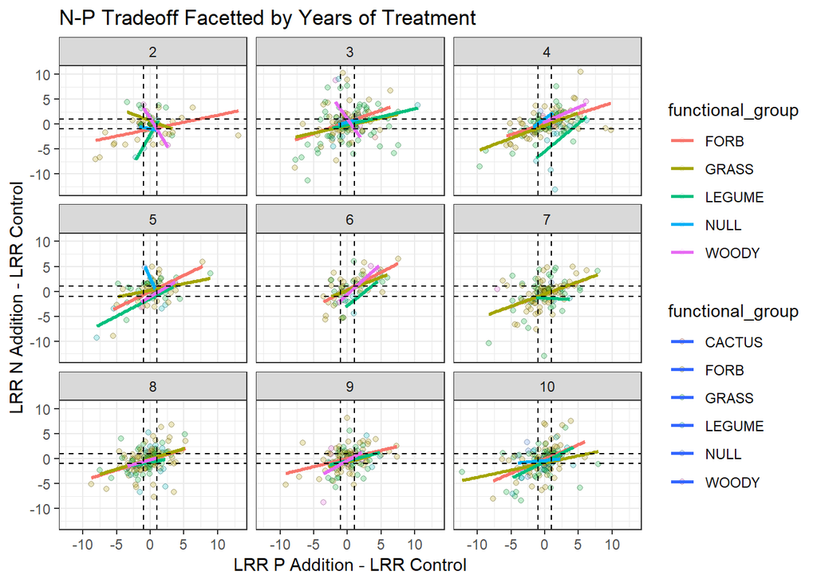

```r
ggplot(coef.npk,
       aes(y=LRR_N,
           x=LRR_P,
           color=functional_group,
           fill=functional_group)) +
  facet_wrap(~nyear_N) +
  geom_point(aes(color = NULL), shape = 21, alpha = .25) +
  geom_smooth(method='lm', se=F) +
  geom_hline(yintercept=-1,linetype='dashed') +
  geom_vline(xintercept=-1,linetype='dashed') +
  geom_hline(yintercept=1,linetype='dashed') +
  geom_vline(xintercept=1,linetype='dashed') +
  theme_bw() +
  labs(x='LRR P Addition - LRR Control',y='LRR N Addition - LRR Control') +
  ggtitle("N-P Tradeoff Facetted by Years of Treatment")
```

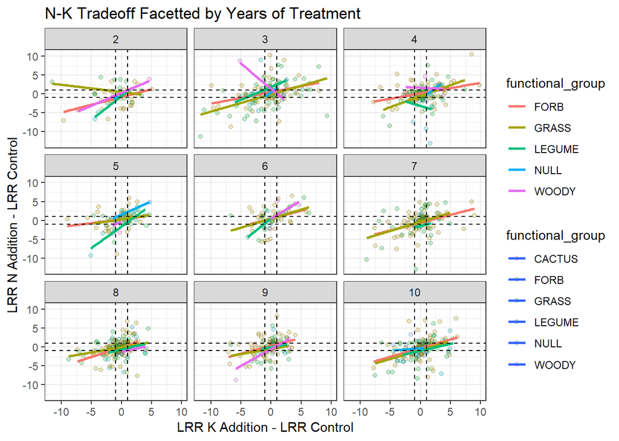

```r
ggplot(coef.npk,
       aes(y=LRR_N,
           x=LRR_K,
           color=functional_group,
           fill=functional_group)) +
  facet_wrap(~nyear_N) +
  geom_point(aes(color = NULL), shape = 21, alpha = .25) +
  geom_smooth(method='lm', se=F) +
  geom_hline(yintercept=-1,linetype='dashed') +
  geom_vline(xintercept=-1,linetype='dashed') +
  geom_hline(yintercept=1,linetype='dashed') +
  geom_vline(xintercept=1,linetype='dashed') +
  theme_bw() +
  labs(x='LRR K Addition - LRR Control',y='LRR N Addition - LRR Control') +
  ggtitle("N-K Tradeoff Facetted by Years of Treatment")
```

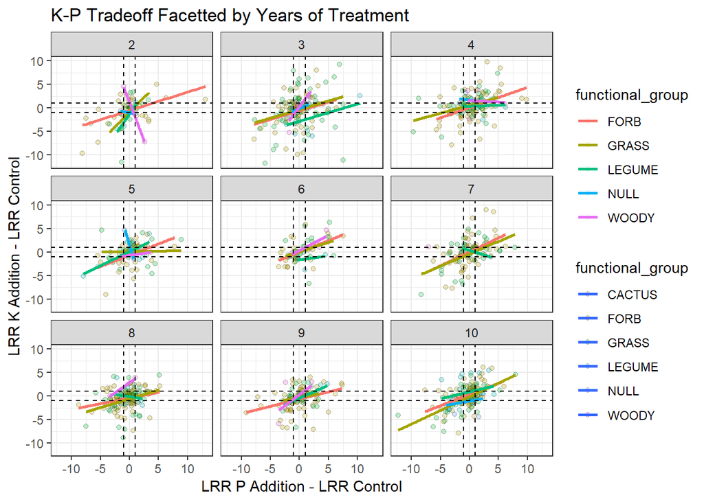

```r
ggplot(coef.npk,
       aes(y=LRR_K,
           x=LRR_P,
           color=functional_group,
           fill=functional_group)) +
  facet_wrap(~nyear_N) +
  geom_point(aes(color = NULL), shape = 21, alpha = .25) +
  geom_smooth(method='lm', se=F) +
  geom_hline(yintercept=-1,linetype='dashed') +
  geom_vline(xintercept=-1,linetype='dashed') +
  geom_hline(yintercept=1,linetype='dashed') +
  geom_vline(xintercept=1,linetype='dashed') +
  theme_bw() +
  labs(x='LRR P Addition - LRR Control',y='LRR K Addition - LRR Control') +
  ggtitle("K-P Tradeoff Facetted by Years of Treatment")
```